# Project 1

Sparsh Kumar

2025-10-10

## 1. Introduction

This project explores data from the 2024 ATP Tour Tennis Tournament. This daatset include information such as match scores, player statistics, court surfaces, etc.

[figure not shown]

Image of an ATP Finals Court (Image from ATP Tour). [Source](https://www.atptour.com/en/corporate/about)

The data is sourced from Jeff Sackmann on GitHub: [GitHub ATP Tour Data](https://github.com/JeffSackmann/tennis_atp)

In this project, I will answer the following research questions:

RQ1- Does a player’s ATP ranking predict their likelihood of winning a match?

RQ2 - Does the type of court surface affect match duration?

## 2. Data Preperation

I started preparing the data by using read.csv to load the dataset into RStudio.

Then, I created two new variables called total_ace (w_ace + l_ace) and rank_spread (winner_rank - loser_rank). I also removed any missing values from the minutes and surface columns.

## 3. Variable Descriptions

```
##      Variable        Type                                  Description
## 1     surface Categorical Type of court surface (Hard, Clay, or Grass)
## 2     minutes     Numeric                    Match duration in minutes
## 3 winner_rank     Numeric                 ATP rank of the match winner
## 4  loser_rank     Numeric                  ATP rank of the match loser
## 5   rank_diff     Numeric    Difference between winner and loser ranks
## 6       w_ace     Numeric                     Aces by the match winner
## 7       l_ace     Numeric                      Aces by the match loser
## 8  total_aces     Numeric                        Total aces in a match
```

## 4. Univariate Analysis

Match Duration:

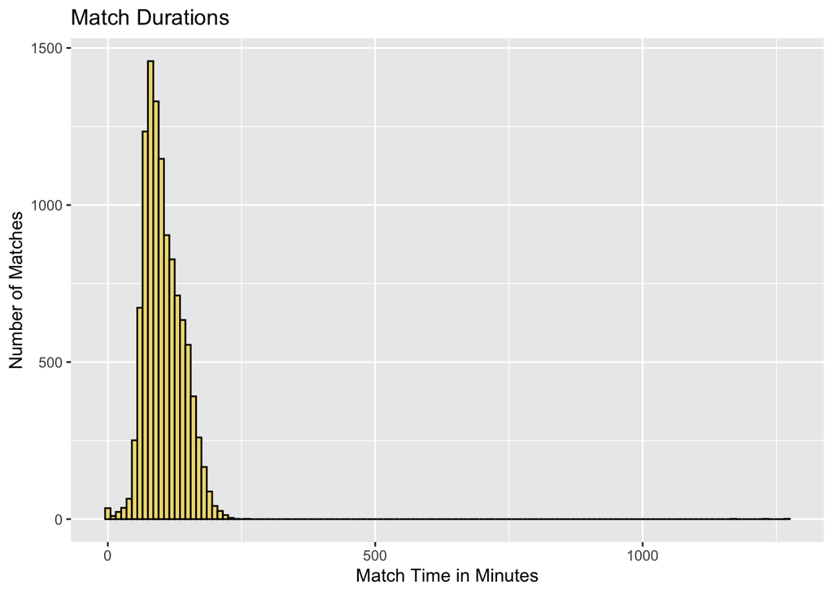

The median match time is 98 minutes. The Interquartile Range of match times is 50 minutes, which means the middle 50% of match durations span approximately 50 minutes. The distribution is skewed right.

Court Surfaces:

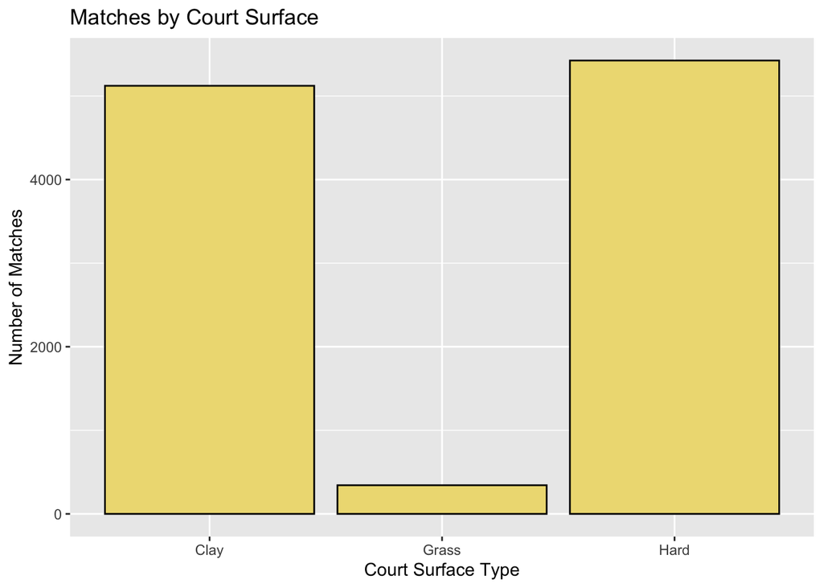

The most common surface is Hard with 5424 matches. This is followed by Clay with 5122 matches. Grass is the least common with 343 matches.

[Different Court Types Info](https://www.playfinder.com/blog/grass-clay-hard-tennis-courts)

Winner Rank:

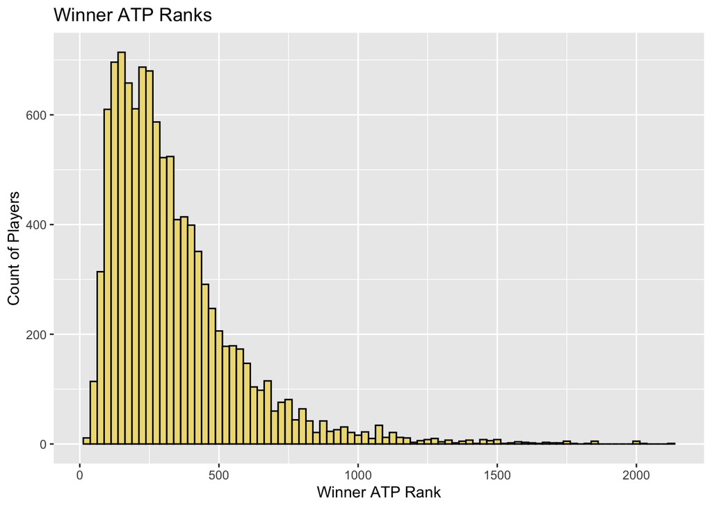

The winner median rank is 276. The Interquartile Range is 250. The distribution is skewed right.

Total Aces:

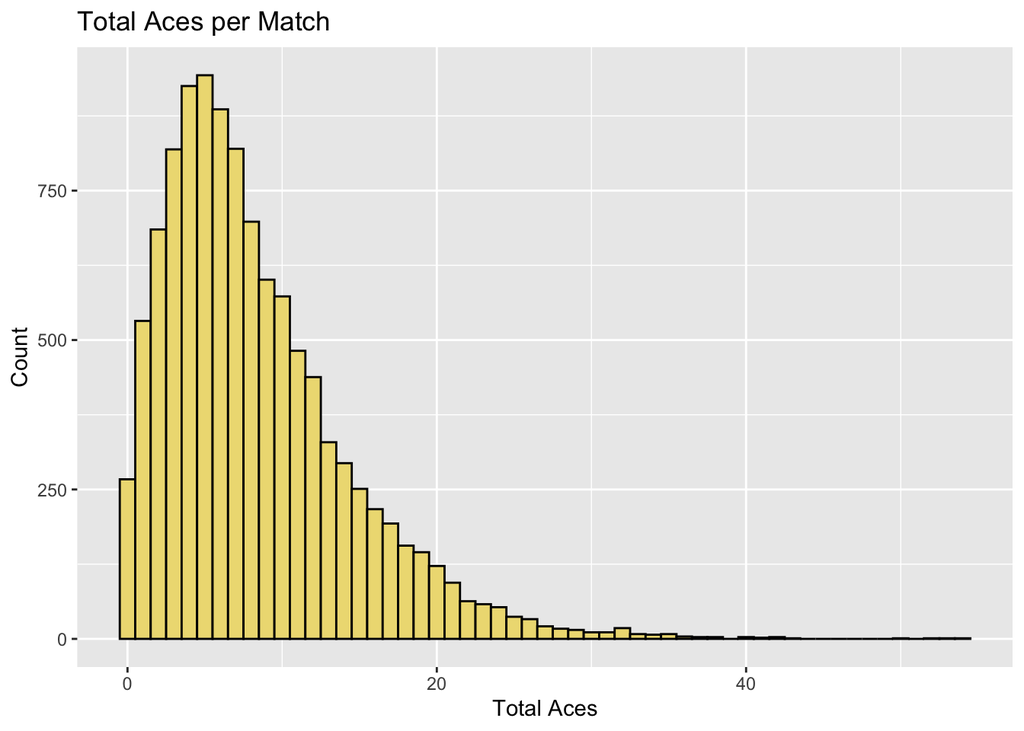

The median of aces per game is 7 aces. The Interquartile Range is 7 aces. The distribution is skewed right.

Aces Definition

## 5. Bivariate Analysis:

Winner vs. Loser Rank:

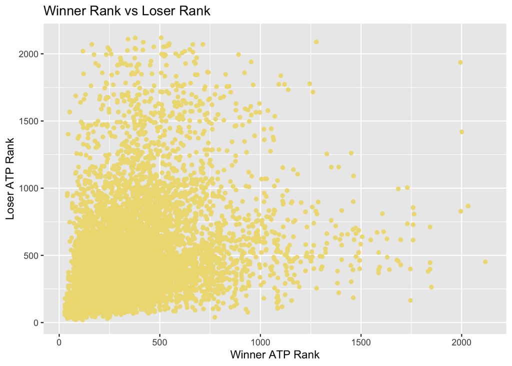

This scatterplot shows the winner versus loser rank. The pearson correlation coefficient is 0.3700395. The scatterplot shows that winner rank is typically lower (better) than loser rank, though there are outliers.

Rank Difference (Winner - Loser) vs. Match Duration:

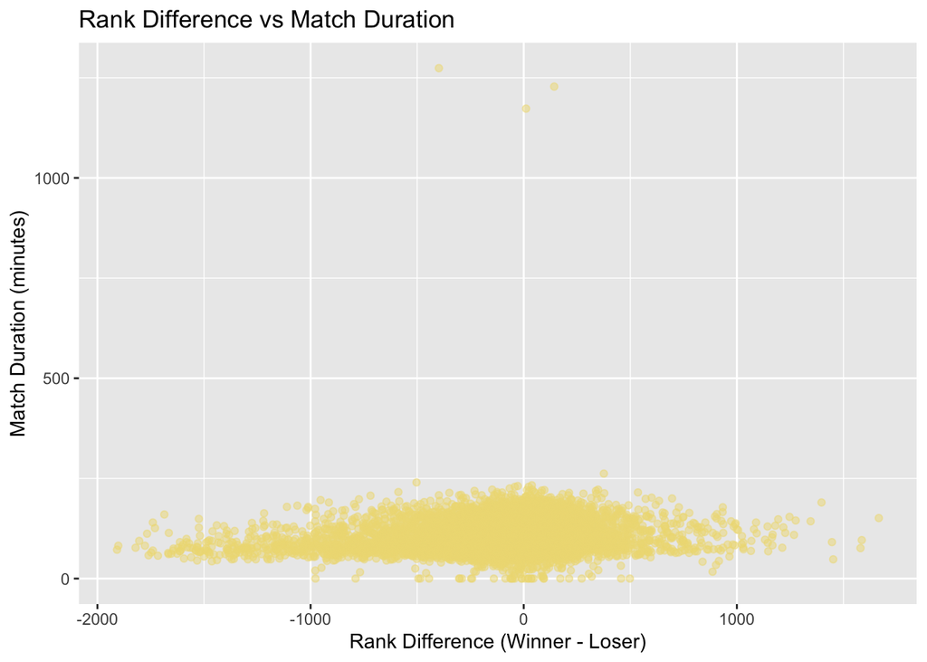

This scatterplot shows the difference in rank versus the duration of the match. The pearson correlation coefficient between the rank difference and match duration is 0.11. This indicates a weak relationship between how close the players ranks are and the length of the match.

Match Duration vs. Surface:

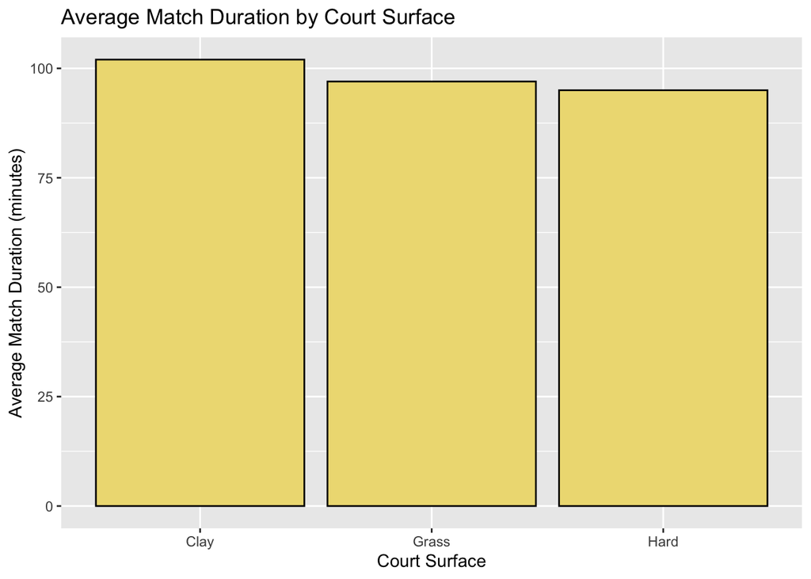

Average Aces for Each Surface:

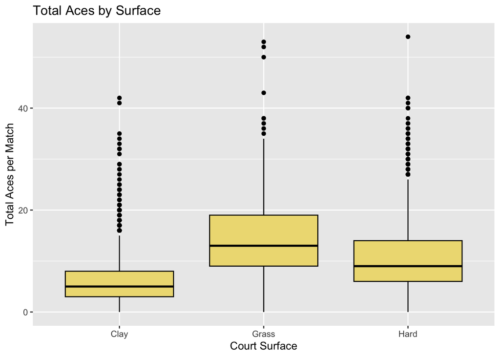

This boxplot shows the average number of aces for each surface of court.

Clay Courts: The median total aces is 5, with an IQR of 5.

Grass Courts: The median total aces is 13, with an IQR of 10.

Hard Courts: The median total aces is 9, with an IQR of 8.

## 6. Choice Elements

I created two new variables of interest using code (choice F) during the data preparation, where I created total_ace and rank_spread. I used inline statistics (choice A) for every univariate and bivariate graph description to show descriptive statistics. I used two hyperlinks, one was to show the different court types, and the other to show was aces are (choice B). I changed the font size in the conclusion at the end to emphasize the results (choice C). I also added a floating table of contents (choice D).

## 7. Conclusion

Lower-ranked (better) players were more likely to win, confirming that ATP ranking predicts match outcomes.  
Clay courts had the longest average match durations (102 minutes), while Hard courts were shortest (95 minutes).

In the future, research could include more years of data to strength the conclusion.

## 8. References

https://stackoverflow.com/questions/45399587/how-to-remove-warning-messages-in-r-markdown-document

https://www.atptour.com/en/corporate/about

https://github.com/JeffSackmann/tennis_atp

https://www.geeksforgeeks.org/r-language/create-table-from-dataframe-in-r/

https://sape.inf.usi.ch/quick-reference/ggplot2/colour

https://www.playfinder.com/blog/grass-clay-hard-tennis-courts

https://en.wikipedia.org/wiki/Ace_(tennis)

https://www.rdocumentation.org/packages/stats/versions/3.6.2/topics/cor